# Introduction of Geospatial Analysis in R studio

Thanakorn Charoensuk bro

2024-12-26

```r
library(tidyverse)
library(ggplot2)
library(stars)      # for raster data
library(sf)         # for vector data
```

## Raster Data

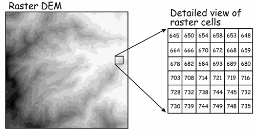

[figure not shown]

```r
dtm_harv <- read_stars("harv/harv_dtmcrop.tif")
dsm_harv <- read_stars("harv/harv_dsmcrop.tif")

chm_harv <- dsm_harv - dtm_harv # Canopy height model (CHM) = DSM - DTM
```

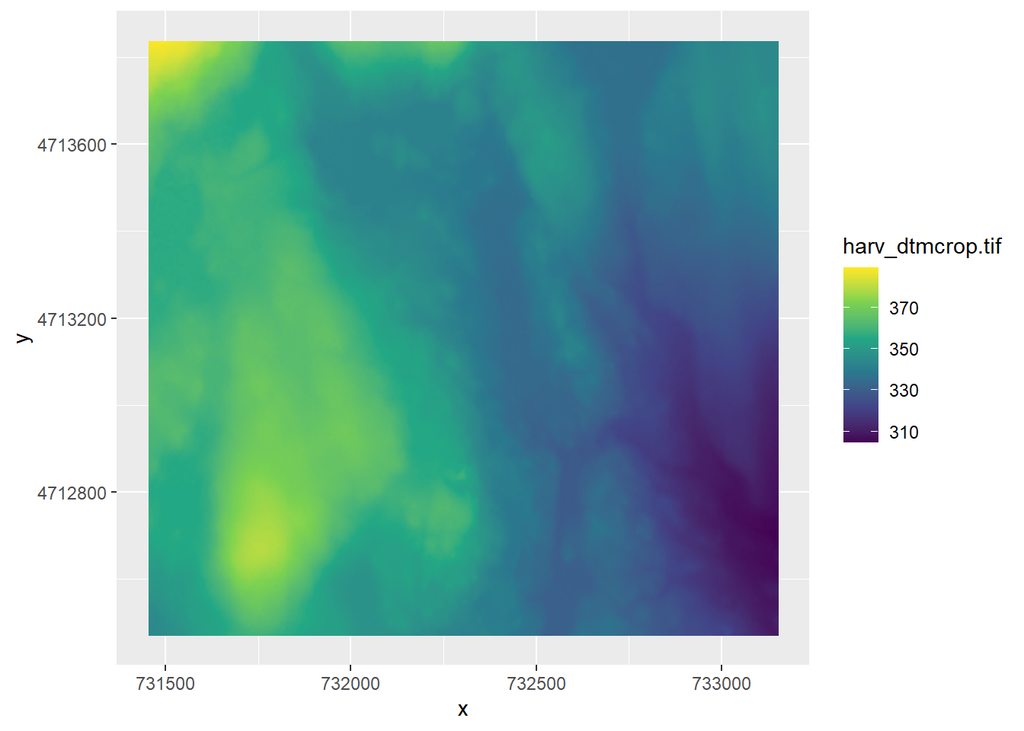

```r
# use ggplot digital terrain model (DTM) data
# DTM = Raster data representing the elevation of the earth's surface

ggplot() +
  geom_stars(data = dtm_harv) +
  scale_fill_viridis_c()
```

#### Plot canopy height model (CHM) data

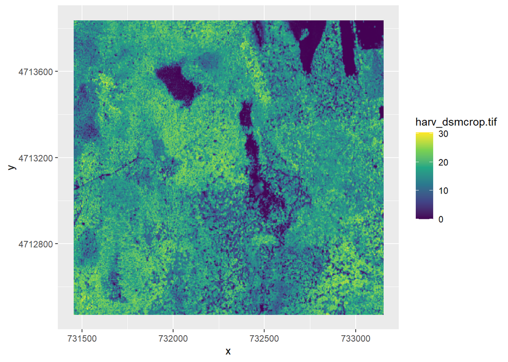

```r
ggplot() +
  geom_stars(data = chm_harv) +
  scale_fill_viridis_c()
```

### Vector Data

[figure not shown]

```r
plots_harv <- st_read("harv/harv_plots.shp")
boundary_harv <- st_read("harv/harv_boundary.shp")
```

#### Plot point data with label in polygons data

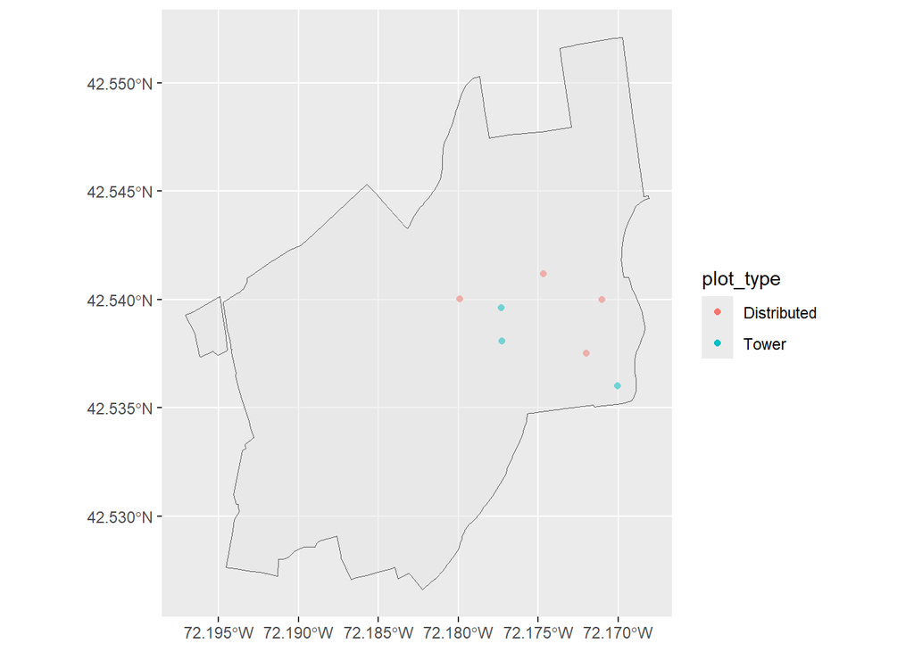

```r
ggplot() +
  geom_sf(data = plots_harv, mapping = aes(color = plot_type)) +
  geom_sf(data = boundary_harv, alpha = 0.5)
```

```r
# The layer sequence is based on code sequence we wrote in ggplot() !!
```

Before, we just working separately with raster and vector data. So let work it together

#### Introduction to Projections

- projection are method that used to represent the curved surface (Earth’s orb) –> flat or 2D (map)
- Example variety for projection, look at figure of US. (Mostly we work with UTM & WGS84
- PROJCRS = Projecttion (e.g., PROJCRS = UTM zone 18N)

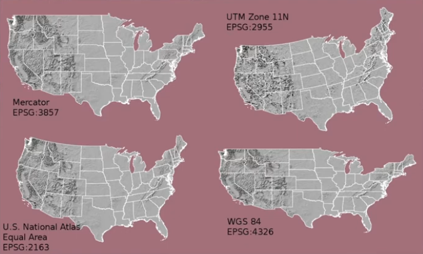

```r
st_crs(dtm_harv)    # check CRS of dtm_harv
```

```
## Coordinate Reference System:
##   User input: WGS 84 / UTM zone 18N
##   wkt:
## PROJCRS["WGS 84 / UTM zone 18N",
##     BASEGEOGCRS["WGS 84",
##         ENSEMBLE["World Geodetic System 1984 ensemble",
##             MEMBER["World Geodetic System 1984 (Transit)"],
##             MEMBER["World Geodetic System 1984 (G730)"],
##             MEMBER["World Geodetic System 1984 (G873)"],
##             MEMBER["World Geodetic System 1984 (G1150)"],
##             MEMBER["World Geodetic System 1984 (G1674)"],
##             MEMBER["World Geodetic System 1984 (G1762)"],
##             MEMBER["World Geodetic System 1984 (G2139)"],
##             MEMBER["World Geodetic System 1984 (G2296)"],
##             ELLIPSOID["WGS 84",6378137,298.257223563,
##                 LENGTHUNIT["metre",1]],
##             ENSEMBLEACCURACY[2.0]],
##         PRIMEM["Greenwich",0,
##             ANGLEUNIT["degree",0.0174532925199433]],
##         ID["EPSG",4326]],
##     CONVERSION["UTM zone 18N",
##         METHOD["Transverse Mercator",
##             ID["EPSG",9807]],
##         PARAMETER["Latitude of natural origin",0,
##             ANGLEUNIT["degree",0.0174532925199433],
##             ID["EPSG",8801]],
##         PARAMETER["Longitude of natural origin",-75,
##             ANGLEUNIT["degree",0.0174532925199433],
##             ID["EPSG",8802]],
##         PARAMETER["Scale factor at natural origin",0.9996,
##             SCALEUNIT["unity",1],
##             ID["EPSG",8805]],
##         PARAMETER["False easting",500000,
##             LENGTHUNIT["metre",1],
##             ID["EPSG",8806]],
##         PARAMETER["False northing",0,
##             LENGTHUNIT["metre",1],
##             ID["EPSG",8807]]],
##     CS[Cartesian,2],
##         AXIS["(E)",east,
##             ORDER[1],
##             LENGTHUNIT["metre",1]],
##         AXIS["(N)",north,
##             ORDER[2],
##             LENGTHUNIT["metre",1]],
##     USAGE[
##         SCOPE["Navigation and medium accuracy spatial referencing."],
##         AREA["Between 78°W and 72°W, northern hemisphere between equator and 84°N, onshore and offshore. Bahamas. Canada - Nunavut; Ontario; Quebec. Colombia. Cuba. Ecuador. Greenland. Haiti. Jamaica. Panama. Turks and Caicos Islands. United States (USA). Venezuela."],
##         BBOX[0,-78,84,-72]],
##     ID["EPSG",32618]]
```

```r
st_crs(plots_harv)  # check CRS of plots_harv (points data)
```

```
## Coordinate Reference System:
##   User input: WGS 84
##   wkt:
## GEOGCRS["WGS 84",
##     DATUM["World Geodetic System 1984",
##         ELLIPSOID["WGS 84",6378137,298.257223563,
##             LENGTHUNIT["metre",1]]],
##     PRIMEM["Greenwich",0,
##         ANGLEUNIT["degree",0.0174532925199433]],
##     CS[ellipsoidal,2],
##         AXIS["latitude",north,
##             ORDER[1],
##             ANGLEUNIT["degree",0.0174532925199433]],
##         AXIS["longitude",east,
##             ORDER[2],
##             ANGLEUNIT["degree",0.0174532925199433]],
##     ID["EPSG",4326]]
```

**Q: So how do we work with spatial data that comes in different projections?**  
A: We can transform all spatial data –> single projection (represent in the same way)

> To transform projections we can use `st_transform()`

```r
dtm_harv_lat_long <- st_transform(dtm_harv, 4326)
st_crs(dtm_harv_lat_long)
```

```
## Coordinate Reference System:
##   User input: EPSG:4326
##   wkt:
## GEOGCRS["WGS 84",
##     ENSEMBLE["World Geodetic System 1984 ensemble",
##         MEMBER["World Geodetic System 1984 (Transit)"],
##         MEMBER["World Geodetic System 1984 (G730)"],
##         MEMBER["World Geodetic System 1984 (G873)"],
##         MEMBER["World Geodetic System 1984 (G1150)"],
##         MEMBER["World Geodetic System 1984 (G1674)"],
##         MEMBER["World Geodetic System 1984 (G1762)"],
##         MEMBER["World Geodetic System 1984 (G2139)"],
##         MEMBER["World Geodetic System 1984 (G2296)"],
##         ELLIPSOID["WGS 84",6378137,298.257223563,
##             LENGTHUNIT["metre",1]],
##         ENSEMBLEACCURACY[2.0]],
##     PRIMEM["Greenwich",0,
##         ANGLEUNIT["degree",0.0174532925199433]],
##     CS[ellipsoidal,2],
##         AXIS["geodetic latitude (Lat)",north,
##             ORDER[1],
##             ANGLEUNIT["degree",0.0174532925199433]],
##         AXIS["geodetic longitude (Lon)",east,
##             ORDER[2],
##             ANGLEUNIT["degree",0.0174532925199433]],
##     USAGE[
##         SCOPE["Horizontal component of 3D system."],
##         AREA["World."],
##         BBOX[-90,-180,90,180]],
##     ID["EPSG",4326]]
```

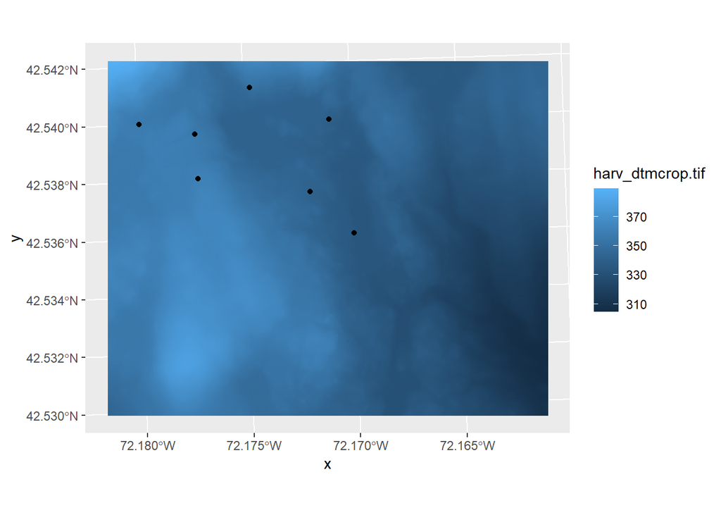

```r
# transform projections of vector (plots_harv) by using raster (dtm_harv)
plots_harv_utm <- st_transform(plots_harv, st_crs(dtm_harv))

# And plot
ggplot() +
  geom_stars(data = dtm_harv) +
  geom_sf(data = plots_harv_utm)
```

## **Mapping Polygons Based on Their Properties**

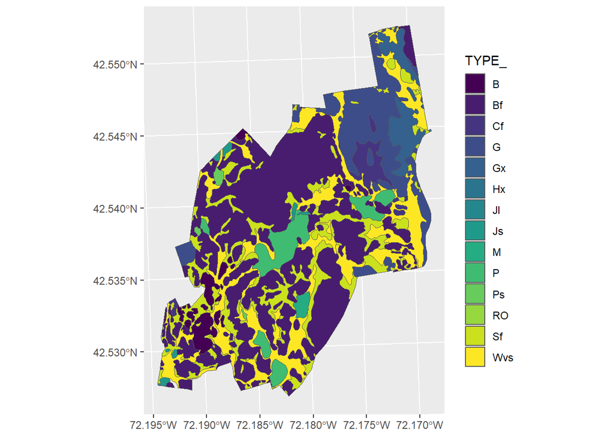

```r
# Soils map data in vector
harv_soils <- st_read("harv/harv_soils.shp")
# PLot soils map
ggplot() +
  geom_sf(data = harv_soils, mapping = aes(fill = TYPE_)) +
  scale_fill_viridis_d()
```

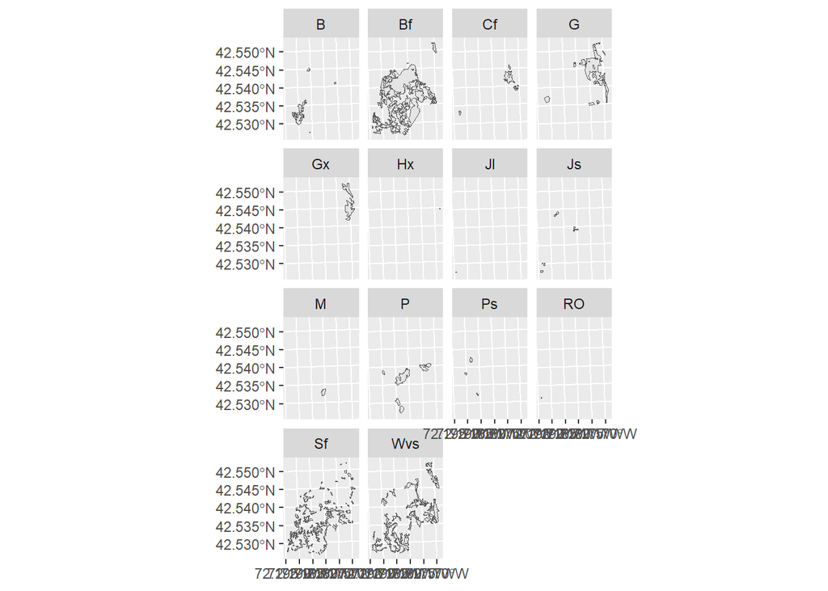

```r
# Sub plot of each soil type
ggplot() +
  geom_sf(data = harv_soils) +
  facet_wrap(~TYPE_)
```

#### Aggregating raster data inside of polygons

it’s like a spatial table join that we do in QGIS and ArcGIS

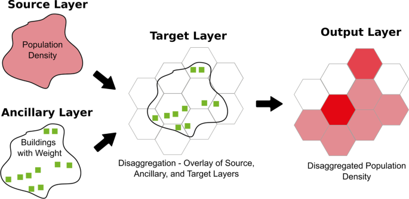

```r
harv_soils <- st_read("harv/harv_soils.shp")
```

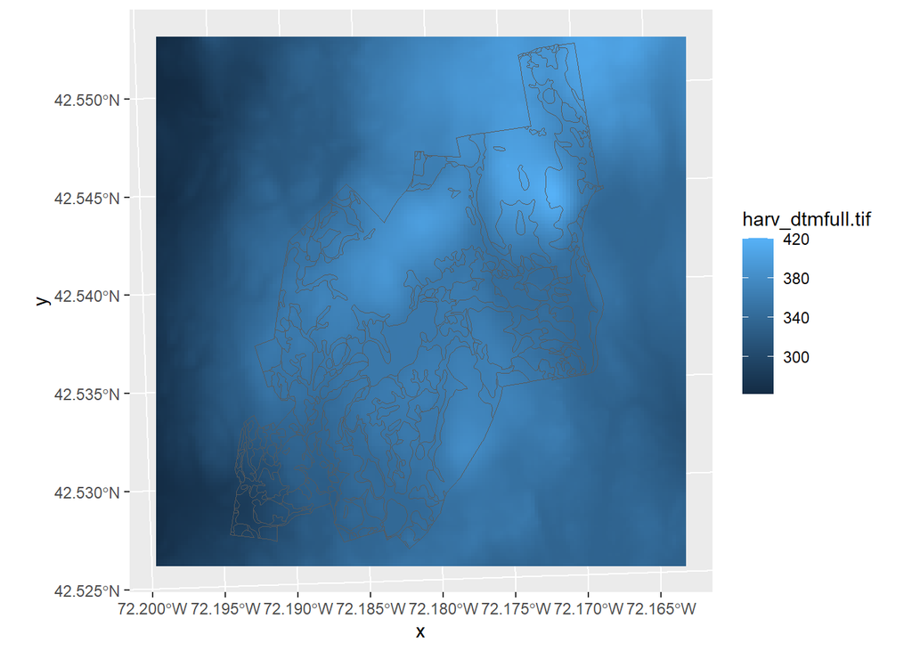

```r
harv_dtm <- read_stars("harv/harv_dtmfull.tif")

ggplot() +
  geom_stars(data = harv_dtm) +
  geom_sf(data = harv_soils, alpha = 0)
```

```r
elevs_by_soil <- aggregate(harv_dtm, harv_soils, mean)
elevs_by_soil$harv_dtmfull.tif
```

```
##   [1] 401.7999 391.7358 390.3411 390.8960       NA 390.2862 390.1273 392.1573 395.9839 397.1992 388.8586 393.3419
##  [13] 369.3172 382.3043 391.7263 377.8303       NA 368.1978 368.7399 390.1999 360.0224 380.2078       NA 383.2409
##  [25] 397.6264 357.4868 369.0623 366.8136 370.2148 367.2131 365.6499 371.3816 407.5957 369.5923 355.7132 351.8456
##  [37] 343.6443 380.9152 356.0843 349.2331 360.3193 372.4685 354.5766       NA 341.8527 367.8968 348.1277 382.2680
##  [49] 345.2243 350.7927 348.6206 344.8640 352.3893 346.4925 349.2485 375.2208 345.1083 361.1494 352.9083 353.6320
##  [61] 352.2054 357.3022 341.8013 361.7240 351.9873 346.6792 348.0114 345.9835 348.1382 349.9501 345.3079 343.0901
##  [73] 343.6794 343.6401 344.2494 345.0650 366.3382 365.9378 343.8476 340.6361 342.2714 342.8546 344.0284 343.8641
##  [85] 344.2674 360.1818 343.1967 344.0983 360.1082 341.1283 359.2284 359.3898 360.6964 352.2419 340.9696 357.7567
##  [97] 353.6626 358.5916 359.2441 342.3707 363.8400 363.0512 359.4515 359.4179 339.9957 362.9401 360.7206 358.9702
## [109] 360.0048 357.8792 339.7693 345.4624 357.1817 357.8474 356.9935 360.8095 355.4320 365.3667 343.6314 359.0835
## [121] 365.7363 362.1328 368.2071 344.4119 338.8640 344.0799 356.8010 352.5619 356.9427 355.4561 351.8205 341.8184
## [133] 353.3373 342.6646 335.1044 344.5246 351.5779 352.7720 359.1788 352.1299 340.3009 360.3747 339.2967 364.3591
## [145] 351.2662 335.9576 360.5861 350.8348 353.2606 340.9088 348.5313 346.3693 368.4802 355.8500 344.3177 361.1897
## [157] 344.8669 330.4193 359.0406 358.8913 357.1661 339.0226 333.6251 324.9610 345.8975 344.1482 335.5096 323.4330
## [169] 314.2648 356.3837 337.4469 334.4486 317.0587 324.5154 352.2210 331.4679 313.9203 342.8091 333.7201 328.3966
## [181] 332.5973 304.5408 354.8273 323.0150 343.1073 354.5920 332.1772 311.5498 329.7933 305.2143 307.7700 313.4499
## [193] 347.4023 347.7199 308.1816 341.1480 294.1271 330.1363 331.7009 328.6155 331.3425 307.5967 294.3869 329.7713
## [205] 323.9264 328.4575 325.9380 290.6257 293.7513 294.2822 326.7820 326.6854 345.9643 339.8767 352.7739 295.9438
## [217] 347.3314 334.7169 301.7458 284.0953 314.9912 340.1013 335.2095       NA 292.3178 283.3478 285.7631 343.7765
## [229] 305.1224 343.4306 343.8149 289.7058 340.0128 303.0522 332.8601 336.6973 337.4289 337.4063 346.8143 294.3862
## [241] 288.9731 334.0004 332.3852       NA 340.2864 344.7596
```

```r
harv_soils <- mutate(harv_soils,
                     elevation = elevs_by_soil$harv_dtmfull.tif)
view(harv_soils)
```

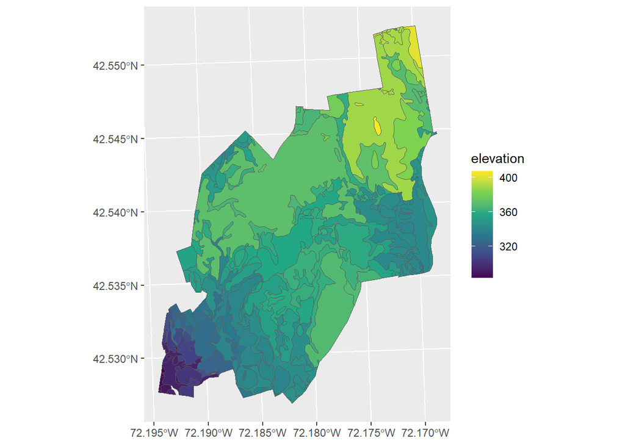

```r
ggplot() +
  geom_sf(data = harv_soils, mapping = aes(fill = elevation)) +
  scale_fill_viridis_c()
```

Q: **How can we maintaining projections when plotting?**  
A: Remember using `"st_cr` `s"` to check CRS  
A: following these steps:

1. Inspect all the data `"sf()"` = vector data, `"raster()"` & `"terra()"` = raster data
2. Define a target coordinate reference system (CRS):  
   Global Analysis: Use WGS84 (EPSG:4326) with latitude and longitude.  
   Local Analysis: Use UTM or a locally appropriate CRS for high precision.  
   For visualization, WGS84 (EPSG:4326) is often preferred
3. Transform projection by using `"st_transform()"` for vector and `"project()"` for raster data
4. Convert to a ggplot2 compatible format `"geom_sf()"` and `"geom_raster()"\`

   > Tips: Always use **EPSG codes** to specify CRS for consistency  
   > Avoid unnecessary transformations to minimize errors.  
   > Use high-precision transformations for scientific accuracy.

Let take a brake with some game :)